# Regression - practice

Polina Zhornikova

26 сентября 2017 г

Пакет для данных:

```r
library(ISLR)
```

Рассмотрим данные Hitters – Major League Baseball Data from the 1986 and 1987 seasons.

- AtBat – Number of times at bat in 1986
- Hits – Number of hits in 1986
- HmRun – Number of home runs in 1986
- Runs – Number of runs in 1986
- RBI – Number of runs batted in in 1986
- Walks – Number of walks in 1986
- Years – Number of years in the major leagues
- CAtBat – Number of times at bat during his career
- CHits – Number of hits during his career
- CHmRun – Number of home runs during his career
- CRuns – Number of runs during his career
- CRBI – Number of runs batted in during his career
- CWalks – Number of walks during his career
- League – A factor with levels A and N indicating player’s league at the end of 1986
- Division – A factor with levels E and W indicating player’s division at the end of 1986
- PutOuts – Number of put outs in 1986
- Assists – Number of assists in 1986
- Errors – Number of errors in 1986
- Salary – 1987 annual salary on opening day in thousands of dollars
- NewLeague – A factor with levels A and N indicating player’s league at the beginning of 1987

```r
str(Hitters)
```

```
## 'data.frame':    322 obs. of  20 variables:
##  $ AtBat    : int  293 315 479 496 321 594 185 298 323 401 ...
##  $ Hits     : int  66 81 130 141 87 169 37 73 81 92 ...
##  $ HmRun    : int  1 7 18 20 10 4 1 0 6 17 ...
##  $ Runs     : int  30 24 66 65 39 74 23 24 26 49 ...
##  $ RBI      : int  29 38 72 78 42 51 8 24 32 66 ...
##  $ Walks    : int  14 39 76 37 30 35 21 7 8 65 ...
##  $ Years    : int  1 14 3 11 2 11 2 3 2 13 ...
##  $ CAtBat   : int  293 3449 1624 5628 396 4408 214 509 341 5206 ...
##  $ CHits    : int  66 835 457 1575 101 1133 42 108 86 1332 ...
##  $ CHmRun   : int  1 69 63 225 12 19 1 0 6 253 ...
##  $ CRuns    : int  30 321 224 828 48 501 30 41 32 784 ...
##  $ CRBI     : int  29 414 266 838 46 336 9 37 34 890 ...
##  $ CWalks   : int  14 375 263 354 33 194 24 12 8 866 ...
##  $ League   : Factor w/ 2 levels "A","N": 1 2 1 2 2 1 2 1 2 1 ...
##  $ Division : Factor w/ 2 levels "E","W": 1 2 2 1 1 2 1 2 2 1 ...
##  $ PutOuts  : int  446 632 880 200 805 282 76 121 143 0 ...
##  $ Assists  : int  33 43 82 11 40 421 127 283 290 0 ...
##  $ Errors   : int  20 10 14 3 4 25 7 9 19 0 ...
##  $ Salary   : num  NA 475 480 500 91.5 750 70 100 75 1100 ...
##  $ NewLeague: Factor w/ 2 levels "A","N": 1 2 1 2 2 1 1 1 2 1 ...
```

Делаем все признаки numeric и убираем NA.

```r
hit <- na.omit(Hitters)
x <- model.matrix(Salary~.,hit)[,-1]
y <- hit$Salary
```

Наблюдений стало:

```r
dim(x)[1]
```

```
## [1] 263
```

Делим на тренировочную и тестовую выборки.

```r
set.seed(1)
train <- sample(1: nrow(x), nrow(x)/2)
test <- - train
y.test <- y[test]
```

Для ridge regression и lasso используем пакет glmnet.

```r
library(glmnet)
```

В glmnet: alpha = 0 – ridge regression, alpha = 1 – lasso.

### Ridge regression

С помощью cross-validation выбираем значение lambda.

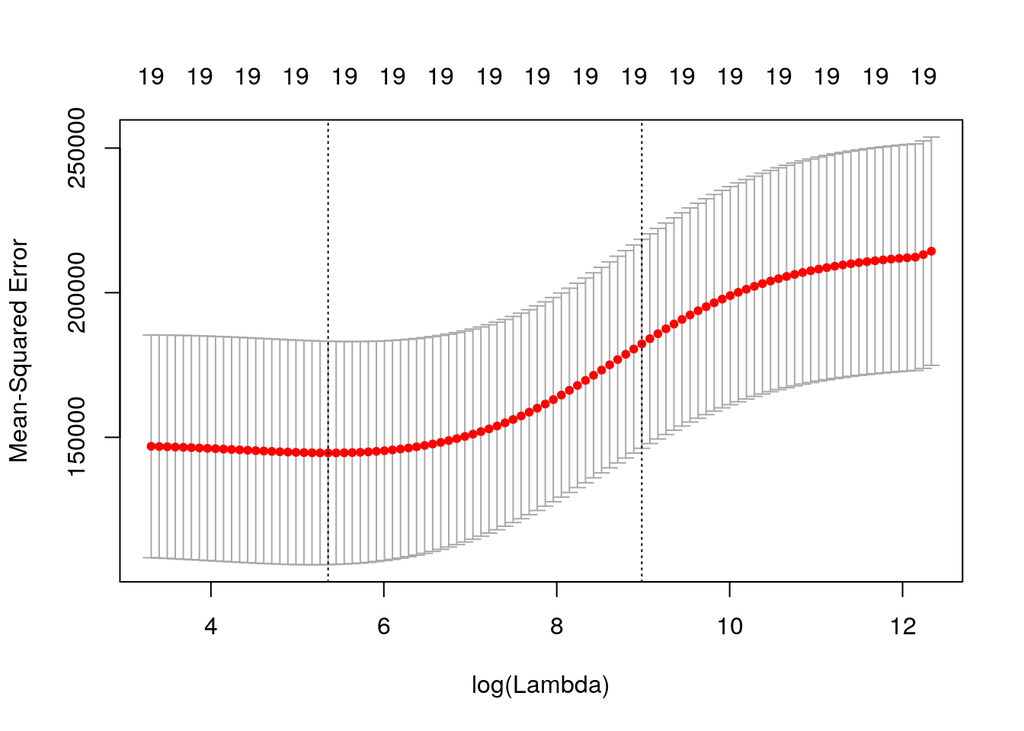

```r
set.seed(1)
cv.out <- cv.glmnet(x[train,],y[train],alpha =0)
plot(cv.out)
```

```r
bestlam <- cv.out$lambda.min
bestlam
```

```
## [1] 211.7416
```

Применяем ridge regression.

```r
ridge.mod <- glmnet(x[train ,],y[train], alpha=0, lambda=bestlam, standardize=TRUE)
ridge.pred <- predict(ridge.mod, s=bestlam, newx=x[test,])
```

Ошибка на тестовой выборке.

```r
sqrt(mean((ridge.pred - y.test)^2))
```

```
## [1] 309.809
```

Посмотрим на сами коэффициенты, они все ненулевые.

```r
predict(ridge.mod, type='coefficients', s=bestlam)[1:20,]
```

```
##   (Intercept)         AtBat          Hits         HmRun          Runs
##  43.956017105  -0.026951053   0.510055782   2.664325096   0.662560049
##           RBI         Walks         Years        CAtBat         CHits
##   0.833735417   3.181895974  -3.526571290   0.009727394   0.059308941
##        CHmRun         CRuns          CRBI        CWalks       League1
##   0.140782930   0.154207867   0.062313544   0.095050630 -19.190703240
##     Division1       PutOuts       Assists        Errors    NewLeague1
##  56.290173916   0.254947507   0.057831532  -0.457120471 -11.066659175
```

### Lasso

С помощью cross-validation выбираем значение lambda.

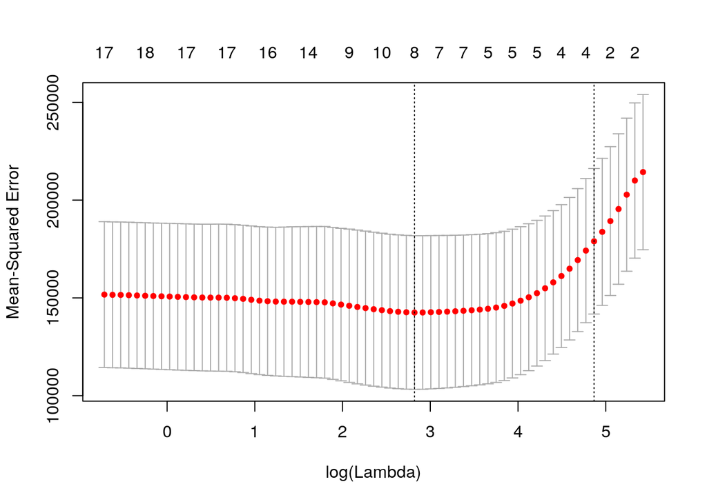

```r
set.seed(1)
cv.out <- cv.glmnet(x[train,],y[train],alpha =1)
plot(cv.out)
```

```r
bestlam <- cv.out$lambda.min
bestlam
```

```
## [1] 16.78016
```

Применяем Lasso

```r
lasso.mod <- glmnet(x[train ,],y[train],alpha=1, lambda=bestlam, standardize=TRUE)
lasso.pred <- predict(lasso.mod, s=bestlam, newx=x[test ,])
```

Ошибка на тестовой выборке.

```r
sqrt(mean((lasso.pred - y.test)^2))
```

```
## [1] 317.504
```

Посмотрим на сами коэффициенты, много нулевых коэффициентов.

```r
predict(lasso.mod, type = 'coefficients',s=bestlam)[1:20,]
```

```
## (Intercept)       AtBat        Hits       HmRun        Runs         RBI
##  30.1183579   0.0000000   0.0182116   1.7260833   0.0000000   0.9712697
##       Walks       Years      CAtBat       CHits      CHmRun       CRuns
##   4.8702230   0.0000000   0.0000000   0.0000000   0.0000000   0.4645674
##        CRBI      CWalks     League1   Division1     PutOuts     Assists
##   0.0000000   0.0000000 -15.2782557  64.8191881   0.3185338   0.0000000
##      Errors  NewLeague1
##   0.0000000   0.0000000
```

### Simple linear regression

```r
lm.pred = predict(ridge.mod, s=0, newx=x[test,], exact=T, x=x[train,], y=y[train])
sqrt(mean((lm.pred - y.test)^2))
```

```
## [1] 339.9801
```

### Модельный пример, когда Ridge regression лучше Lasso.

Можно ожидать, что Ridge regression будет лучше работать, когда y зависит от многих признаков, имеющих примерно одинаковые коэффициенты.

```r
set.seed(17)
y <- 0
x <- matrix(0, 100, 50)
for (i in (1:50)){
  x[,i] <- rnorm(100)
}
y <- apply(x, 1, sum)
set.seed(1)
train <- sample(1: nrow(x), nrow(x)/2)
test <- - train
y.test <- y[test]
```

#### Rigde regression

```r
set.seed(1)
cv.out <- cv.glmnet(x[train,],y[train],alpha =0)
bestlam <- cv.out$lambda.min
ridge.mod <- glmnet(x[train ,],y[train],alpha=0, lambda=bestlam, standardize=TRUE)
ridge.pred <- predict(ridge.mod, s=bestlam, newx=x[test ,])
```

Ошибка на тестовой выборке.

```r
sqrt(mean((ridge.pred - y.test)^2))
```

```
## [1] 5.615583
```

#### Lasso

```r
set.seed(1)
cv.out <- cv.glmnet(x[train,],y[train],alpha =1)
bestlam <- cv.out$lambda.min
lasso.mod <- glmnet(x[train ,],y[train],alpha=1, lambda=bestlam, standardize=TRUE)
lasso.pred <- predict(lasso.mod, s=bestlam, newx=x[test ,])
```

Ошибка на тестовой выборке.

```r
sqrt(mean((lasso.pred - y.test)^2))
```

```
## [1] 6.320816
```

### Модельный пример, когда Lasso лучше Ridge regression.

Можно ожидать, что Lasso будет лучше работать, когда имеется много признаков с маленькими значениями коэффициентов (мало информативных признаков).

```r
set.seed(17)
y <- 0
x <- matrix(0, 100, 50)
x[,1] <- (1:100)
for (i in (2:46)){
  x[,i] <- rnorm(100) * 0.000001
}
for (i in (47:50)){
  x[,i] <- rnorm(100)
}
y <- apply(x, 1, sum)
set.seed(1)
train <- sample(1: nrow(x), nrow(x)/2)
test <- - train
y.test <- y[test]
```

#### Rigde

```r
set.seed(1)
cv.out <- cv.glmnet(x[train,],y[train],alpha =0)
bestlam <- cv.out$lambda.min
ridge.mod <- glmnet(x[train ,],y[train],alpha=0, lambda=bestlam, standardize=TRUE)
ridge.pred <- predict(ridge.mod, s=bestlam, newx=x[test ,])
```

Ошибка на тестовой выборке.

```r
sqrt(mean((ridge.pred - y.test)^2))
```

```
## [1] 28.99477
```

#### Lasso

```r
set.seed(1)
cv.out <- cv.glmnet(x[train,],y[train],alpha =1)
bestlam <- cv.out$lambda.min
lasso.mod <- glmnet(x[train ,],y[train],alpha=1, lambda=bestlam,
thresh=1e-7, standardize=TRUE)
lasso.pred <- predict(lasso.mod, s=bestlam, newx=x[test ,])
```

Ошибка на тестовой выборке.

```r
sqrt(mean((lasso.pred - y.test)^2))
```

```
## [1] 1.202327
```